# Assignment2_rev2

billy

2023-03-23

# The data

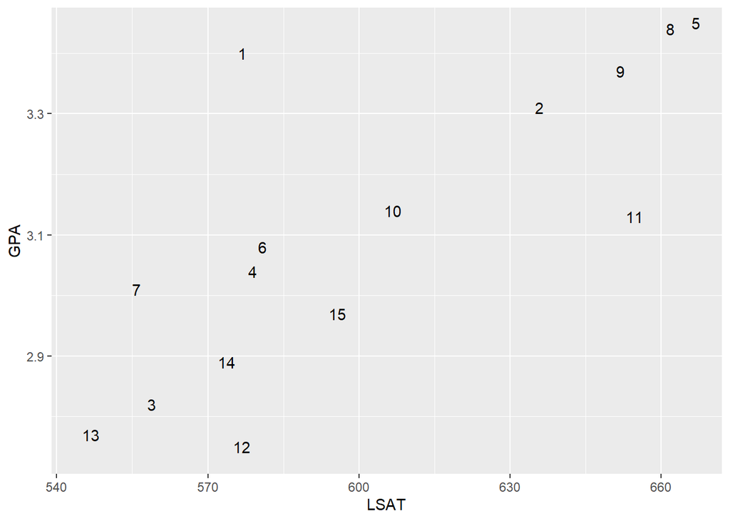

```r
library("ggplot2")
library("tibble")
library("bootstrap")
library("magrittr")
data(law)
law %<>% add_column(observation = 1:nrow(law), .before = 1)
ggplot(law, aes(x = LSAT, y = GPA)) +
geom_text(aes(label = observation),
hjust = 0, vjust = 0)
```

#Compute the nonparametric bootstrap distribution of the Pearson’s correlation coefficient between LSAT and GPA using B = 40000 bootstrap samples.

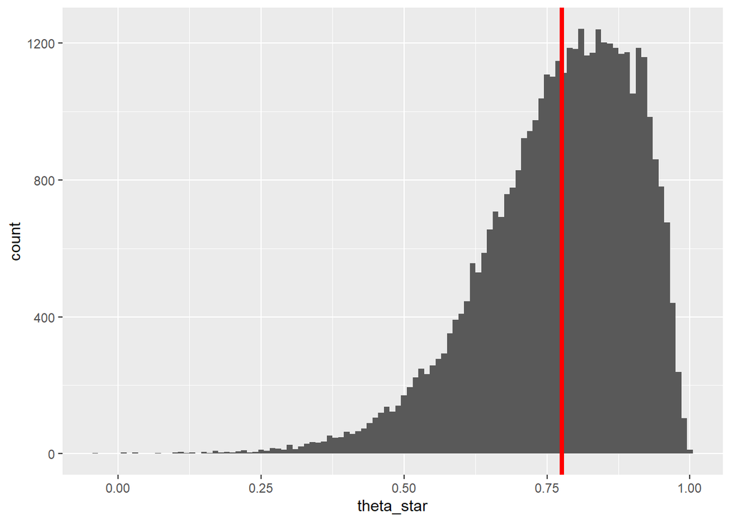

```r
theta_hat <- cor(law$LSAT,law$GPA)
boot <- function() {
n = nrow(law)
ind = sample(n, replace = TRUE)
cor(law[ind,]$LSAT, law[ind,]$GPA)
}
B <- 40000
theta_star <- replicate(B, boot())
ggplot(tibble(theta_star), aes(theta_star)) + geom_histogram(binwidth = 0.01) +
geom_vline(xintercept = theta_hat, colour = "red", size = 1.5)
```

#Recompute using the complete enumeration bootstrap.

```
n_obs <- length(law$observation)
enum <- 1:n_obs

which_bin <- function(x) {
  return(floor(x*100)+101)
}
corr_bin_count <- vector("double", 200)

for (a in enum) {
  for (b in enum) {
    for (c in enum) {
      for (d in enum) {
        for (e in enum) {
          for (f in enum) {
            for (g in enum) {
              for (h in enum) {
                for (i in enum) {
                  for (j in enum) {
                    for (k in enum) {
                      for (l in enum) {
                        for (m in enum) {
                          for (n in enum) {
                            for (o in enum) {
                              indices <- c(a,b,c,d,e,f,g,h,i,j,k,l,m,n,o)
                              correl <- cor(law$LSAT[indices], law$GPA[indices])
                              index <- which_bin(correl)
                              corr_bin_count[index] = corr_bin_count[index] + 1
                            }
                          }
                        }
                      }
                    }
                  }
                }
              }
            }
          }
        }
      }
    }
  }
}
```

It consumes more than 20 hrs to run the code.

#to implement the Monte Carlo procedure (parametric bootstrap) to compute the distribution of the Pearson’s correlation coefficient between LSAT and GPA, you can follow these steps:

1. Calculate the sample Pearson’s correlation coefficient (r) between LSAT and GPA using the observed data.
2. Assume a parametric distribution for the population (e.g., assume that the population follows a bivariate normal distribution).
3. Use the observed data to estimate the parameters of the assumed distribution (e.g., estimate the means and variances of the two variables, and the correlation coefficient between them).
4. Generate a large number of synthetic datasets (e.g., 10,000) of the same size as the observed data, using the estimated distribution parameters.
5. For each synthetic dataset, calculate the Pearson’s correlation coefficient between LSAT and GPA.
6. Compute the empirical distribution of the Pearson’s correlation coefficients obtained in step 5 (e.g., by calculating the mean, standard deviation, percentiles, etc.). This empirical distribution represents the sampling distribution of the Pearson’s correlation coefficient under the assumed population distribution.
7. Use the empirical distribution obtained in step 6 to estimate the standard error of the Pearson’s correlation coefficient and to construct confidence intervals or hypothesis tests.
8. Compare the observed Pearson’s correlation coefficient (from step 1) with the empirical distribution (from step 6) to assess its statistical significance.

In summary, the Monte Carlo procedure (parametric bootstrap) involves generating synthetic datasets from an assumed population distribution and using them to obtain the sampling distribution of a statistic (in this case, the Pearson’s correlation coefficient). This approach is useful when no analytical solution is available or when the population distribution is not known.

Implementing with the “law” dataset:

```r
# Load the data
data <- data.frame(
  LSAT = c(576, 635, 558, 578, 666, 580, 555, 661, 651, 605, 653, 575, 545, 572, 594),
  GPA = c(3.39, 3.30, 2.81, 3.03, 3.44, 3.07, 3.00, 3.43, 3.36, 3.13, 3.12, 2.74, 2.76, 2.88, 2.96)
)

# Calculate the observed Pearson's correlation coefficient
obs_r <- cor(data$LSAT, data$GPA)

# Define the assumed population distribution (bivariate normal)
pop_mean <- c(mean(data$LSAT), mean(data$GPA))
pop_var <- cov(data)
pop_dist <- mvtnorm::rmvnorm(n = nrow(data), mean = pop_mean, sigma = pop_var)

# Generate a large number of synthetic datasets
n_synth <- 10000
synth_data <- replicate(n_synth, mvtnorm::rmvnorm(n = nrow(data), mean = pop_mean, sigma = pop_var), simplify = FALSE)

# Calculate the Pearson's correlation coefficient for each synthetic dataset
synth_r <- sapply(synth_data, function(x) cor(x[,1], x[,2]))

# Compute the empirical distribution of the Pearson's correlation coefficient
mean_synth_r <- mean(synth_r)
sd_synth_r <- sd(synth_r)
quantiles_synth_r <- quantile(synth_r, probs = c(0.025, 0.975))

# Print the results
cat("Observed Pearson's correlation coefficient: ", obs_r, "\n")
```

```
## Observed Pearson's correlation coefficient:  0.7763745
```

```r
cat("Mean synthetic Pearson's correlation coefficient: ", mean_synth_r, "\n")
```

```
## Mean synthetic Pearson's correlation coefficient:  0.7653718
```

```r
cat("Standard deviation of synthetic Pearson's correlation coefficient: ", sd_synth_r, "\n")
```

```
## Standard deviation of synthetic Pearson's correlation coefficient:  0.1188145
```

```r
cat("95% confidence interval of synthetic Pearson's correlation coefficient: [", quantiles_synth_r[1], ",", quantiles_synth_r[2], "]\n")
```

```
## 95% confidence interval of synthetic Pearson's correlation coefficient: [ 0.4726234 , 0.9250111 ]
```

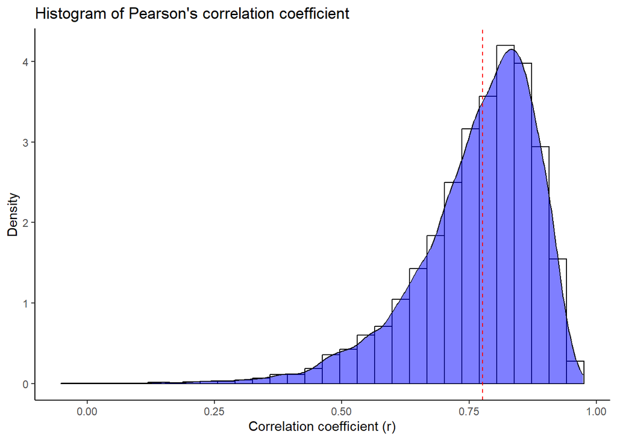

```r
library(ggplot2)

# Convert the synthetic Pearson's correlation coefficients to a data frame
synth_r_df <- data.frame(r = synth_r)

# Plot the histogram
ggplot(synth_r_df, aes(x = r)) +
  geom_histogram(aes(y = ..density..), bins = 30, color = "black", fill = "white") +
  geom_density(alpha = 0.5, fill = "blue") +
  geom_vline(xintercept = obs_r, color = "red", linetype = "dashed") +
  labs(title = "Histogram of Pearson's correlation coefficient",
       x = "Correlation coefficient (r)",
       y = "Density") +
  theme_classic()
```

This code will produce a histogram with a density curve of the synthetic Pearson’s correlation coefficients, a vertical dashed line at the location of the observed Pearson’s correlation coefficient, and x and y axis labels.